# Exploring Global Terrorism Data

24 April 2016

## Outline

- Global Terrorism Database
- Why Terrorism?
- Terrorism by the Numbers
- Terrorism Globally
- Closing Remarks

## Global Terrorism Database

## Global Terrorism Database

- Maintained by National Consortium for the Study of Terrorism and Responses to Terrorism (START)
- A research and education center for the study of the causes and effects of terrorism around the world

## Global Terrorism Database

- A Center of Excellence by the Department of Homeland Security
- Headquartered at the University of Maryland

## Global Terrorism Database

- A highly comprehensive and consistent terrorism incident dataset from 1970 to 2014
- Data collection methodology consists of a combination of automated and manual data collection strategies of over a million media articles worldwide
- Filtered using natural language processing and machine learning techniques

## Why Terrorism?

## Why Terrorism?

[figure not shown]

- Americans say terrorism is the most important issue facing the US
- Highest percentage of Americans to mention terrorism in a decade

## Why Terrorism?

- What is the average number of attacks per year?
- What are the types of attacks?
- How do casualties compare across different attacks?

## Terrorism by the Numbers

## Terrorism by the Numbers

- Since 1970, there have been about 3,227 terrorist attacks a year
- On average, there are 7,046 deaths a year due to terrorist attacks

## Terrorism by the Numbers

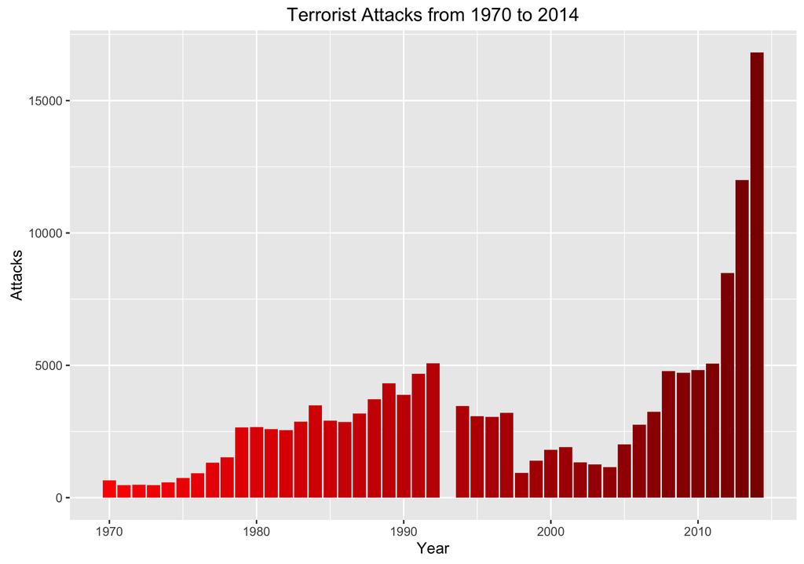

- The number of attacks look to have fallen in the 90s and then increased steadily in beginning 2005

## Terrorism by the Numbers

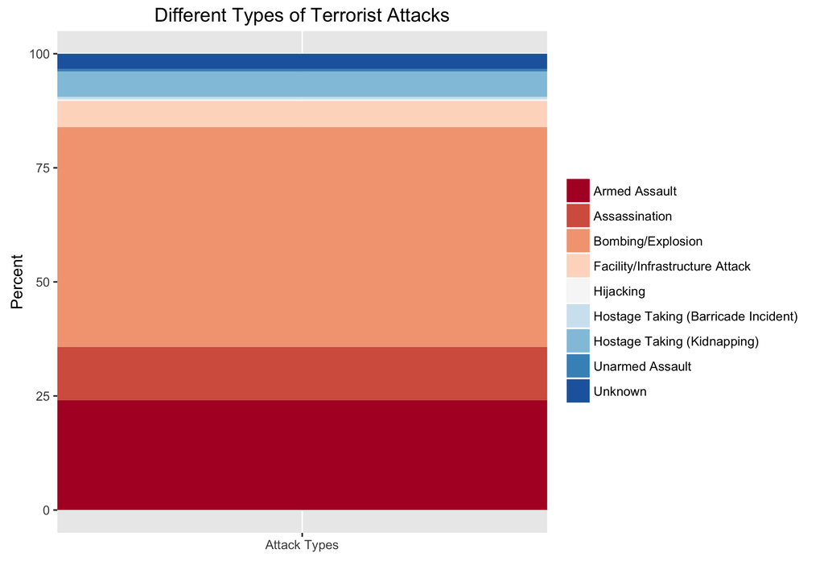

- Almost half of all attacks were of the bombing/explosion type
- The second and third most common were armed assault and assassination at 24% and 12%, respectively

## Terrorism by the Numbers

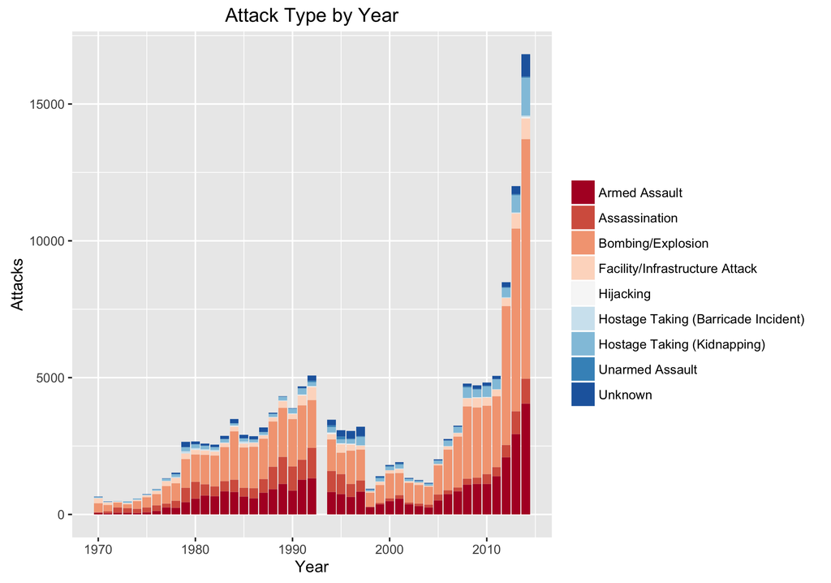

- The increase in number of attacks in recent years was driven by the bombing/explosion type

## Terrorism by the Numbers

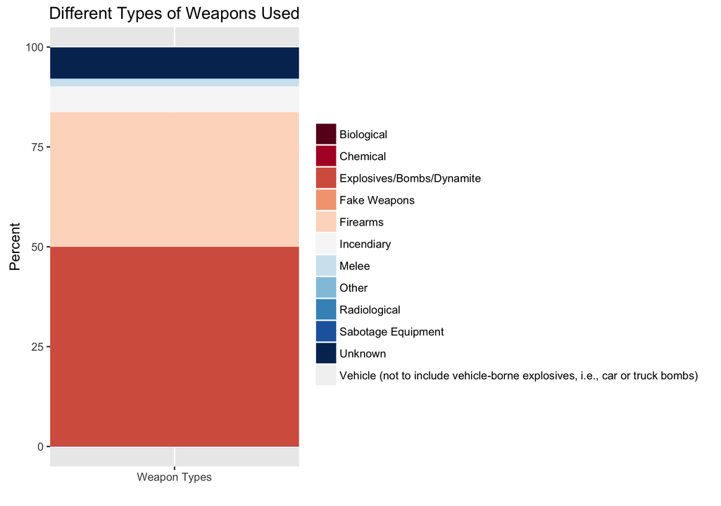

- Half of all attacks consisted of explosives
- 33% consisted of firearms

## Terrorism by the Numbers

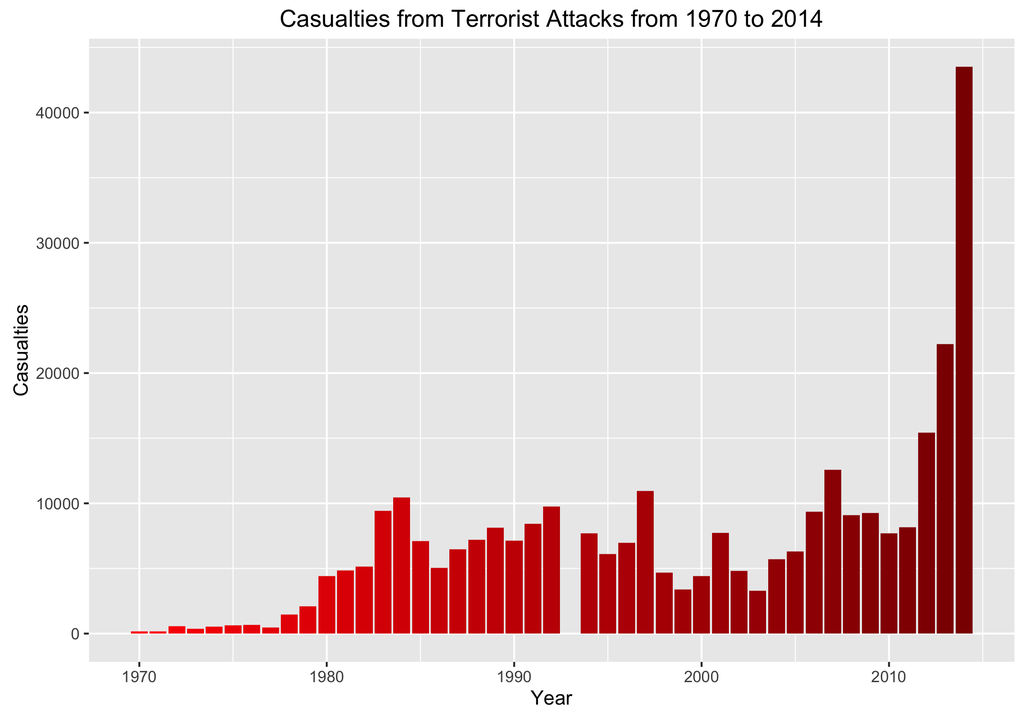

- Interestingly, casualties decreased from 2007 to 2011

## Terrorism by the Numbers

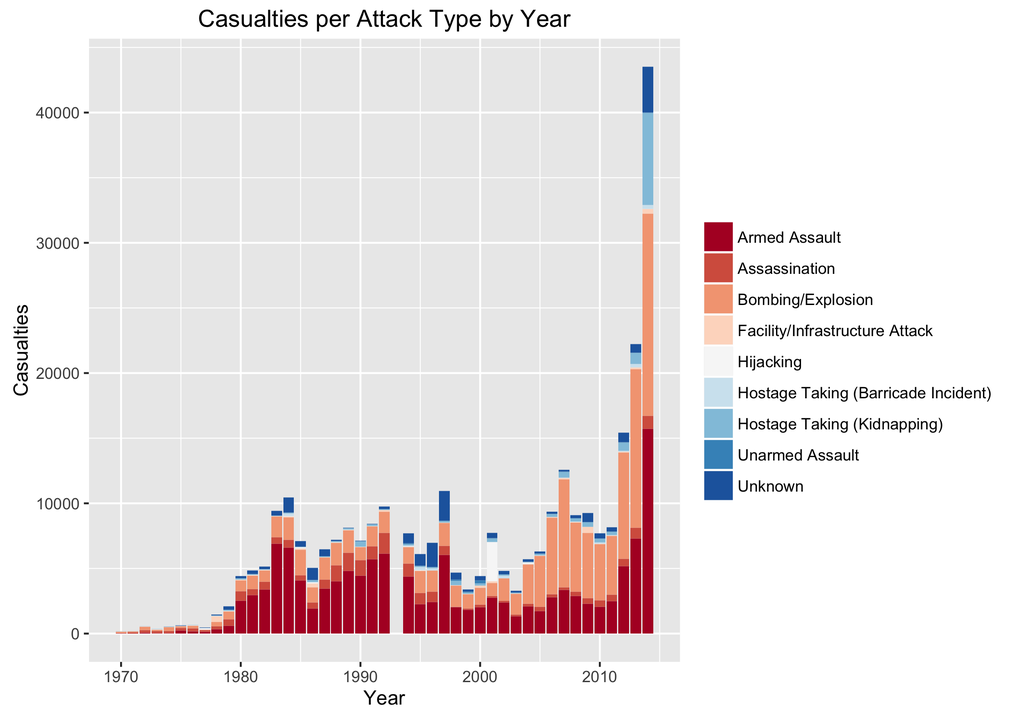

- Prior to 2004, armed assault was the primary cause of deaths
- Only in the last decade did bombing/explosion attacks overtake armed assault in terms of casualties

## Closing Remarks

## Closing Remarks

Findings:

## Closing Remarks

Future exploration:

- How did casualties per attack change through time?
- What specific countries started experiencing more attacks in recent years?
- What were the possible causes in the changes of number of attacks throughout the years?